# **Exploratory Analysis of multiple factors and CO2 Emission in United States**

## **Final Tutorial Notebook**

### Group Member Name: Li Zechen

[⭐Link to Github.io website](https://zcli48.github.io/)

[⭐Link to Github page contain all dataset](https://github.com/zcli48/zcli48.github.io)

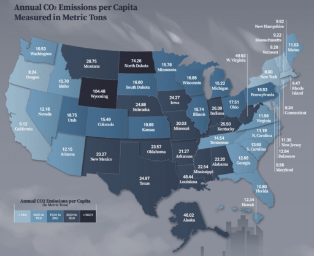

# Project Outline:

1. Introduction
2. Data Extraction, Transform and Load (ETL)
3. Exploratory Data Analysis (EDA)
4. Proposed Model
5. Conclusion

# **Part 1: Introduction**

## **Project Plan**

Carbon dioxide enters our atmosphere from both human and natural activity, though human activity has been responsible for the majority of greenhouse gas emissions in the past 150 years. The biggest culprit is burning fossil fuels like oil, coal, and natural gas for transportation and heat.

The goal of this project is to analyze different factors such as the average income, the relationships among the workforce and average wage of car dealers and the CO2 emissions in different states in United States. The project aims to gain insights into how these factors interact with each other and try to get deeper understanding. By examining these relationships, we seek to answer questions such as:

1. What is the relationship between the average wage of car dealers and the workforce of car dealers in the state?
2. Can we identify any trends or patterns that suggest the impact of car dealerships on CO2 emissions or vice versa?
3. What are other factors(for example: average income, temperature) that affect the CO2 emissions?
4. How can we use the result to reduce the CO2 emission?

Resources:

1. U.S. states ranked by carbon dioxide emissions: https://solarpower.guide/solar-energy-insights/states-ranked-carbon-dioxide-emissions
2. Average wage and workforce of Car dealers in U.S. states: https://datausa.io/profile/naics/car-dealers?workforceByStates=wage
3. Average income and population by State: https://datausa.io/map?measure=2pNPMW&groups%5B0%5D=Z1NAx1v%7C0&time=2021
4. State energy-related carbon dioxide emissions by year: https://www.eia.gov/environment/emissions/state/
5. Statewide Average Temperature from 2014-2020: https://www.ncei.noaa.gov/access/monitoring/climate-at-a-glance/statewide/mapping/110/tavg/202012/12/value

### **Why this topic matter?**

Carbon dioxide emissions are among the primary contributing factors of climate change. In order to slow the negative effects of climate change, it’s important to know the key factors that affect the CO2 emissions and the relation between them.

This project holds the potential to contribute valuable insights into the complex interactions between economic activities, workforce dynamics, and environmental impact. By addressing the outlined objectives, it aim to provide actionable recommendations for reducing CO2 emissions.

### **Discussion of why the data I'm using is correct:**

The datasets I used: Average wage and workforce of Car dealers in U.S. states/Average wage and population by State/State energy-related carbon dioxide emissions/average income/average temperature by year are strongly related to the questions I want to solve and from reliable source, I do the ETL to remove data not required, make sure they are clean and combine them using inner join. Make sure I get a merged dataset full of useful data.

## **Collaboration Plan**

As a graduate student, I will work on this project individually.

# **Part 2: Data Extraction, Transform and Load (ETL)**

First, identify the sources of datasets, scrape and download the datasets, exploring the raw data to understand its structure. Use Pandas convert them to dataframe, loaded them. Then tidied them by reset index, fix missing values, change column names, delete unneeded rows and columns and so on.

```python
!pip3 install lxml
import requests
from bs4 import BeautifulSoup
import pandas as pd
import numpy as np
import lxml
import matplotlib.pyplot as plt
import re
import seaborn as sns
from scipy.stats import linregress
from scipy.stats import pearsonr
# display option
pd.set_option("display.max_rows", None, "display.max_columns", None)
```

[output not shown]

**For dataset part, I extract tables from different sources, Do the transformation and tidying, then combine them to a merged table for using.**

**Table1 and Table2**

Table1 and Table2 are from the Data USA. Data USA is set of curated data, mostly reposts of other things findable from other places but in easier to use formats. The 2 datasets provides information about the wage and workforce in the car dealership industry for various states in the year 2020. They includes data on workforce status and unique identifiers for states, years, and industry groups, as well as the state names and slug representations.

The dataset may provide insight to questions like:

1. In which states the car dealership industry is developed?
2. Is there any relationship between wage and workforce of car dealers?

[Link of table1 and table2](https://datausa.io/profile/naics/car-dealers?workforceByStates=wage)

```python
wage = pd.read_csv(r'wage.csv')
wage.head()
```

|  | ID State | State | ID Year | Year | ID Industry Group | Industry Group | ID Workforce Status | Workforce Status | Average Wage | Slug State |
| --- | --- | --- | --- | --- | --- | --- | --- | --- | --- | --- |
| 0 | 04000US72 | Puerto Rico | 2020 | 2020 | 4411 | Car Dealers | True | True | 25262.858482 | puerto-rico |
| 1 | 04000US01 | Alabama | 2020 | 2020 | 4411 | Car Dealers | True | True | 47640.432508 | alabama |
| 2 | 04000US02 | Alaska | 2020 | 2020 | 4411 | Car Dealers | True | True | 52611.651941 | alaska |
| 3 | 04000US04 | Arizona | 2020 | 2020 | 4411 | Car Dealers | True | True | 59807.053203 | arizona |
| 4 | 04000US05 | Arkansas | 2020 | 2020 | 4411 | Car Dealers | True | True | 56431.590377 | arkansas |

```python
workforce = pd.read_csv(r'workforce.csv')
workforce.head()
```

|  | ID State | State | ID Year | Year | ID Industry Group | Industry Group | ID Workforce Status | Workforce Status | Total Population | Slug State |
| --- | --- | --- | --- | --- | --- | --- | --- | --- | --- | --- |
| 0 | 04000US72 | Puerto Rico | 2020 | 2020 | 4411 | Car Dealers | True | True | 6720 | puerto-rico |
| 1 | 04000US01 | Alabama | 2020 | 2020 | 4411 | Car Dealers | True | True | 19343 | alabama |
| 2 | 04000US02 | Alaska | 2020 | 2020 | 4411 | Car Dealers | True | True | 2241 | alaska |
| 3 | 04000US04 | Arizona | 2020 | 2020 | 4411 | Car Dealers | True | True | 29923 | arizona |
| 4 | 04000US05 | Arkansas | 2020 | 2020 | 4411 | Car Dealers | True | True | 11098 | arkansas |

First, merge the 2 table, drop the features we do not need, then uniform the wage by round it to 1 decimal place. Rename columns, generate a new feature 'Total Wage' which is average wage*population, then check for missing values.

```python
dealer = pd.merge(wage, workforce)

columns_to_drop = [
    'ID State',
    'ID Year',
    'ID Industry Group',
    'Industry Group',
    'ID Workforce Status',
    'Workforce Status',
    'Slug State'
]

# drop the columns
dealer.drop(columns=columns_to_drop, inplace=True)

dealer['Average Wage'] = dealer['Average Wage'].round(1)# round to 1 demical place

dealer.rename(columns={'Average Wage': 'Average Wage(USD)'}, inplace=True)
dealer['Total Wage(M USD)'] = (dealer['Average Wage(USD)'] * dealer['Total Population']) / 1000000 #generate new feature
dealer['Total Wage(M USD)'] = dealer['Total Wage(M USD)'].round(1)

missing_values = dealer.isna().sum()
print(missing_values) # check for missing value
dealer.head()
```

```
State                0
Year                 0
Average Wage(USD)    0
Total Population     0
Total Wage(M USD)    0
dtype: int64
```

|  | State | Year | Average Wage(USD) | Total Population | Total Wage(M USD) |
| --- | --- | --- | --- | --- | --- |
| 0 | Puerto Rico | 2020 | 25262.9 | 6720 | 169.8 |
| 1 | Alabama | 2020 | 47640.4 | 19343 | 921.5 |
| 2 | Alaska | 2020 | 52611.7 | 2241 | 117.9 |
| 3 | Arizona | 2020 | 59807.1 | 29923 | 1789.6 |
| 4 | Arkansas | 2020 | 56431.6 | 11098 | 626.3 |

Find rows 'Puerto Rico' and 'District of Columbia' which are not state in table dealer, remove them.

```python
# find unique state
dealer = dealer[(dealer['State'] != 'Puerto Rico') & (dealer['State'] != 'District of Columbia')]
dealer.reset_index(drop=True, inplace=True)
dimensions1 = dealer.shape
print(f"Dimension: {dimensions1[0]} × {dimensions1[1]}")
dealer.head()

# dtype
dealer.dtypes

# print unique states
#print(unique_dealer.tolist())
```

```
Dimension: 350 × 5
```

```
State                 object
Year                   int64
Average Wage(USD)    float64
Total Population       int64
Total Wage(M USD)    float64
dtype: object
```

**Table 3**

Average income and population by State 2014 - 2021

The dataset may provide insight to questions like:

1. In which states the average income is higher?
2. Is there any relationship between average income and CO2 emission?

[Link of table3](https://datausa.io/map?measure=2pNPMW&groups%5B0%5D=Z1NAx1v%7C0&time=2021)

```python
income = pd.read_csv(r'income.csv')
# drop column
income = income.drop(columns=['ID Geography'])
# rename columns
income = income.rename(columns={'Geography': 'State'})

# drop the year and place
income = income[(income['Year'] != 2021)&(income['Year'] != 2013)]
income = income[(income['State'] != 'District of Columbia') & (income['State'] != 'Puerto Rico')]
income = income.reset_index(drop=True)
income.head()
```

|  | Year | State | Average Income | Population |
| --- | --- | --- | --- | --- |
| 0 | 2020 | Alabama | 28799.847599 | 4893186 |
| 1 | 2020 | Alaska | 37177.117605 | 736990 |
| 2 | 2020 | Arizona | 32026.752796 | 7174064 |
| 3 | 2020 | Arkansas | 27403.629367 | 3011873 |
| 4 | 2020 | California | 38387.107422 | 39346023 |

```python
income.dtypes
```

```
Year                int64
State              object
Average Income    float64
Population          int64
dtype: object
```

**Table 4**

State energy-related carbon dioxide emissions by year. Total state CO2 emissions include CO2 emissions from direct fuel use across all sectors, including residential, commercial, industrial, and transportation, as well as primary fuels consumed for electricity generation.

The dataset may provide insight to questions like:

1. Which are the states with high CO2 emission and low CO2 emission?
2. Is there any common ground between them?

[Link of table4](https://www.eia.gov/environment/emissions/state/)

```python
emission = pd.read_excel('emission.xlsx')

# drop data we don't need
emission = emission.iloc[:, :-4]
emission = emission.iloc[3:]
emission = emission.drop(emission.columns[1:45], axis=1)

# reform the dataset
emission = emission.transpose()
emission.columns = emission.iloc[0]
emission = emission.reset_index(drop=True)
emission = emission.rename(columns={'State': 'Year'})
emission = pd.melt(emission, id_vars=['Year'], var_name='State', value_name='Annual CO2 Emissions (Millions of Metric Tons)')

emission = emission.iloc[1:]
emission = emission[(emission.index <= 458) & (emission['Year'] != 2021) & (emission['State'] != 'District of Columbia') & (emission['Year'] != 'State')]
emission['Year'] = emission['Year'].astype(int)
emission['Annual CO2 Emissions (Millions of Metric Tons)'] = pd.to_numeric(emission['Annual CO2 Emissions (Millions of Metric Tons)'], errors='coerce')

# sort by year and state
emission = emission.sort_values(by=['Year', 'State'], ascending=[False, True])
emission = emission.reset_index(drop=True)
emission.head()
```

|  | Year | State | Annual CO2 Emissions (Millions of Metric Tons) |
| --- | --- | --- | --- |
| 0 | 2020 | Alabama | 98.431803 |
| 1 | 2020 | Alaska | 35.977743 |
| 2 | 2020 | Arizona | 80.153897 |
| 3 | 2020 | Arkansas | 54.749619 |
| 4 | 2020 | California | 303.815453 |

```python
emission.dtypes
```

```
Year                                                int64
State                                              object
Annual CO2 Emissions (Millions of Metric Tons)    float64
dtype: object
```

**Table5**

Statewide Average Temperature from 2014-2020

The dataset may provide insight to questions like:

1. Is there any relationship between temperature income and CO2 emission?

[Link of table5](https://www.ncei.noaa.gov/access/monitoring/climate-at-a-glance/statewide/mapping/110/tavg/202012/12/value)

```python
years = range(2014, 2021)
columns_to_drop = ['Rank', 'Anomaly (1901-2000 base period)', '1901-2000 Mean', 'ID']

temp = pd.concat(
    [pd.read_csv(f'{year}.csv').drop(columns=columns_to_drop).rename(columns={'Name': 'State'}).assign(Year=year) for year in years],
    ignore_index=True
)
```

```python
temp.dtypes
```

```
State     object
Value    float64
Year       int64
dtype: object
```

**The full, cleaned dataset is shown below:**

**Create a merged table:**

```python
merged_df = emission.merge(income, on=['State', 'Year'], how='inner')
merged_df = merged_df.merge(dealer, on=['State', 'Year'], how='inner')
merged_df = merged_df.merge(temp, on=['State', 'Year'], how='inner')
merged_df.rename(columns={'Value': 'Temperature'}, inplace=True)
merged_df['Annual CO2 Emissions per Capita (Metric Tons)'] = (merged_df['Annual CO2 Emissions (Millions of Metric Tons)'] / merged_df['Population']) * 1_000_000
merged_df.head()
```

|  | Year | State | Annual CO2 Emissions (Millions of Metric Tons) | Average Income | Population | Average Wage(USD) | Total Population | Total Wage(M USD) | Temperature | Annual CO2 Emissions per Capita (Metric Tons) |
| --- | --- | --- | --- | --- | --- | --- | --- | --- | --- | --- |
| 0 | 2020 | Alabama | 98.431803 | 28799.847599 | 4893186 | 47640.4 | 19343 | 921.5 | 64.9 | 20.116097 |
| 1 | 2020 | Arizona | 80.153897 | 32026.752796 | 7174064 | 59807.1 | 29923 | 1789.6 | 62.6 | 11.172732 |
| 2 | 2020 | Arkansas | 54.749619 | 27403.629367 | 3011873 | 56431.6 | 11098 | 626.3 | 61.2 | 18.177931 |
| 3 | 2020 | California | 303.815453 | 38387.107422 | 39346023 | 60617.6 | 126539 | 7670.5 | 60.5 | 7.721631 |
| 4 | 2020 | Colorado | 79.911265 | 39459.537495 | 5684926 | 57648.8 | 20966 | 1208.7 | 47.3 | 14.056694 |

```python
merged_df.dtypes
```

```
Year                                                int64
State                                              object
Annual CO2 Emissions (Millions of Metric Tons)    float64
Average Income                                    float64
Population                                          int64
Average Wage(USD)                                 float64
Total Population                                    int64
Total Wage(M USD)                                 float64
Temperature                                       float64
Annual CO2 Emissions per Capita (Metric Tons)     float64
dtype: object
```

## **Part 3: Exploratory Data Analysis (EDA)**

### **Plot 1: Average Wage and Total Population**

The scatter plot of Average Wage and Total Population can show us if there is a relationship between wage and workforce. We can see there may exist a positive relationship and some outliers.

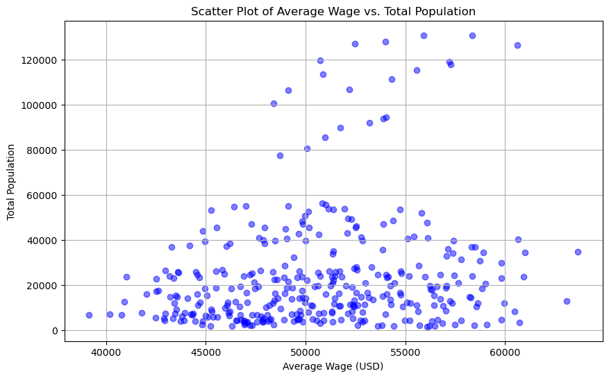

```python
plt.figure(figsize=(10, 6))
plt.scatter(dealer['Average Wage(USD)'], dealer['Total Population'], c='blue' ,alpha = 0.5)
plt.title('Scatter Plot of Average Wage vs. Total Population')
plt.xlabel('Average Wage (USD)')
plt.ylabel('Total Population')
plt.grid(True)

plt.show()
```

**Analysis:**

We can see there seems to be a positive relationship between Average Wage and Total Population of car dealers, there are also some special cases have large total population in higher average wage part.

### **Plot 2: Average Average Wage(USD) and Average Total Population in Dealer for Each Year**

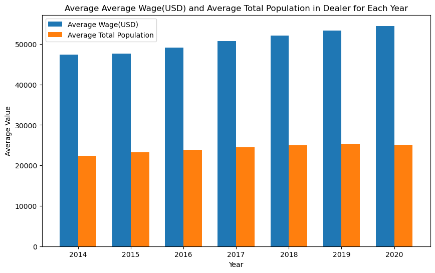

```python
average_data_by_year = dealer.groupby('Year').agg({'Average Wage(USD)': 'mean', 'Total Population': 'mean'}).reset_index()

plt.figure(figsize=(10, 6))
bar_width = 0.35
index = average_data_by_year['Year']

# create bars
plt.bar(index, average_data_by_year['Average Wage(USD)'], bar_width, label='Average Wage(USD)')
plt.bar(index + bar_width, average_data_by_year['Total Population'], bar_width, label='Average Total Population')
plt.xlabel('Year')
plt.ylabel('Average Value')
plt.title('Average Average Wage(USD) and Average Total Population in Dealer for Each Year')
plt.xticks(index + bar_width / 2, index)
plt.legend()

plt.show()
```

**Analysis:**

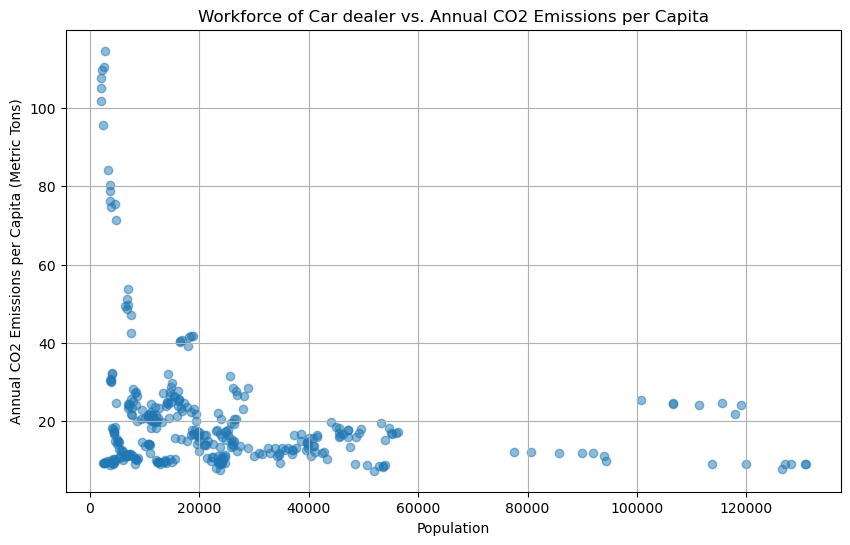

```python
# Create a scatter plot
plt.figure(figsize=(10, 6))
plt.scatter(merged_df['Total Population'], merged_df['Annual CO2 Emissions per Capita (Metric Tons)'], alpha = 0.5)
plt.title('Workforce of Car dealer vs. Annual CO2 Emissions per Capita')
plt.xlabel('Population')
plt.ylabel('Annual CO2 Emissions per Capita (Metric Tons)')
plt.grid(True)

plt.show()
```

**Analysis:**

We can see the states with large population always have lower CO2 Emissions per Capita, and states have high CO2 Emissions per Capita gather in small workforce part.

Since we make an assumption that there may be a relationship between average income and CO2 emission per capita, draw a scatter plot of Average Income vs. Annual CO2 Emissions per Capita.

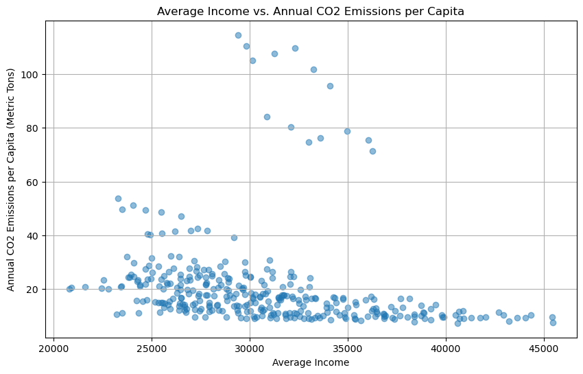

```python
plt.figure(figsize=(10, 6))
plt.scatter(merged_df['Average Income'], merged_df['Annual CO2 Emissions per Capita (Metric Tons)'], alpha = 0.5)
plt.title('Average Income vs. Annual CO2 Emissions per Capita')
plt.xlabel('Average Income')
plt.ylabel('Annual CO2 Emissions per Capita (Metric Tons)')
plt.grid(True)

plt.show()
```

**Analysis:**

There seems to be a negative relationship between Average Income and Annual CO2 Emissions per Capita. Which means higher income may cause lower CO2 emission.

### **Plot 5: Car Dealer Percentage vs. Annual CO2 Emissions per Capita**

If we want to know the relationship between workfoce and CO2 emission, we can not use work force directly, but rather the proportion. So we bring in the dataset of population by States and calculute the proportion of car dealer workforce.

```python
merged_df['Car Dealer Percentage'] = 100* merged_df['Total Population'] / merged_df['Population']
```

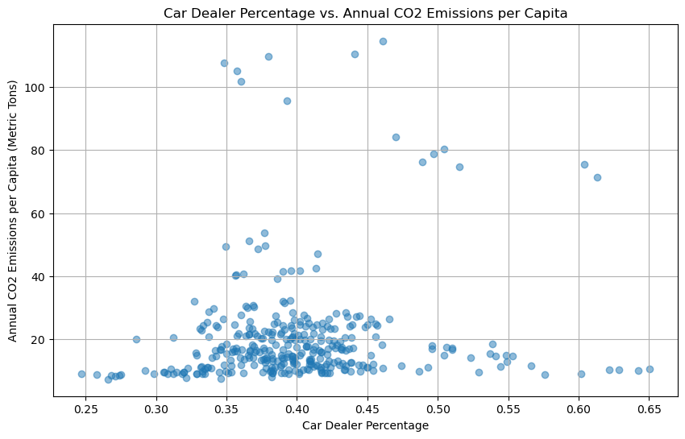

```python
plt.figure(figsize=(10, 6))
plt.scatter(merged_df['Car Dealer Percentage'], merged_df['Annual CO2 Emissions per Capita (Metric Tons)'], alpha=0.5)
plt.title('Car Dealer Percentage vs. Annual CO2 Emissions per Capita')
plt.xlabel('Car Dealer Percentage')
plt.ylabel('Annual CO2 Emissions per Capita (Metric Tons)')
plt.grid(True)

plt.show()
```

**Analysis:**

There seems to be no direct relationship.

### **Plot 6: Average Temperature vs. Annual CO2 Emissions per Capita**

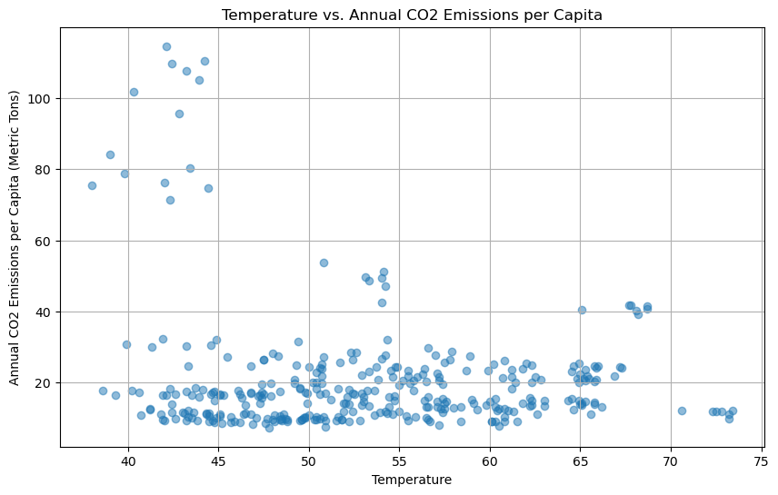

```python
plt.figure(figsize=(10, 6))
plt.scatter(merged_df['Temperature'], merged_df['Annual CO2 Emissions per Capita (Metric Tons)'], alpha = 0.5)
plt.title('Temperature vs. Annual CO2 Emissions per Capita')
plt.xlabel('Temperature')
plt.ylabel('Annual CO2 Emissions per Capita (Metric Tons)')
plt.grid(True)

plt.show()
```

**Analysis:**

In some special cases of cold states the CO2 emission is high, but generally there is not a clear relationship.

# **Part 4: Proposed Model**

## **Proposed Model 1: Model of average income and CO2 emission per capita**

**I plan to use average income in a state to predict the annual CO2 emissions per capita.**

Independent Variable (X): Average Income in a State (USD)

Dependent Variable (Y): Annual CO2 Emissions per Capita (Metric Tons)

Methodology: Linear Regression Model/Quadratic Regression Model

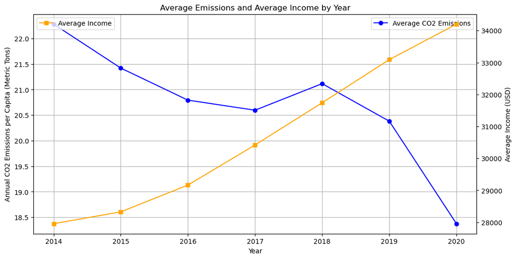

```python
average_emission_by_year = merged_df.groupby('Year')['Annual CO2 Emissions per Capita (Metric Tons)'].mean()
average_income_by_year = merged_df.groupby('Year')['Average Income'].mean()

plt.figure(figsize=(12, 6))
plt.plot(average_emission_by_year.index, average_emission_by_year, marker='o', linestyle='-', label='Average CO2 Emissions', color='blue')
plt.title('Average Emissions and Average Income by Year')
plt.xlabel('Year')
plt.ylabel('Annual CO2 Emissions per Capita (Metric Tons)')
plt.grid(True)
plt.legend()
plt.twinx()
plt.plot(average_income_by_year.index, average_income_by_year, marker='s', linestyle='-', label='Average Income', color='orange')
plt.ylabel('Average Income (USD)')
plt.legend()
plt.show()
```

From the central tendency we can see that there is a trend for income to increase over time and for emission to decrease, especially in 2020. Since they changed every year, we need to do the standardilzation.

**Standardized CO2 emission and income:**

```python
# the emission and income change across years, standardize them
average_emission_by_year = merged_df.groupby('Year')['Annual CO2 Emissions per Capita (Metric Tons)'].transform('mean')
std_dev_emission_by_year = merged_df.groupby('Year')['Annual CO2 Emissions per Capita (Metric Tons)'].transform('std')

merged_df['Standardized CO2 Emissions'] = (merged_df['Annual CO2 Emissions per Capita (Metric Tons)'] - average_emission_by_year) / std_dev_emission_by_year

average_income_by_year = merged_df.groupby('Year')['Average Income'].transform('mean')
std_dev_income_by_year = merged_df.groupby('Year')['Average Income'].transform('std')

merged_df['Standardized Average Income'] = (merged_df['Average Income'] - average_income_by_year) / std_dev_income_by_year
```

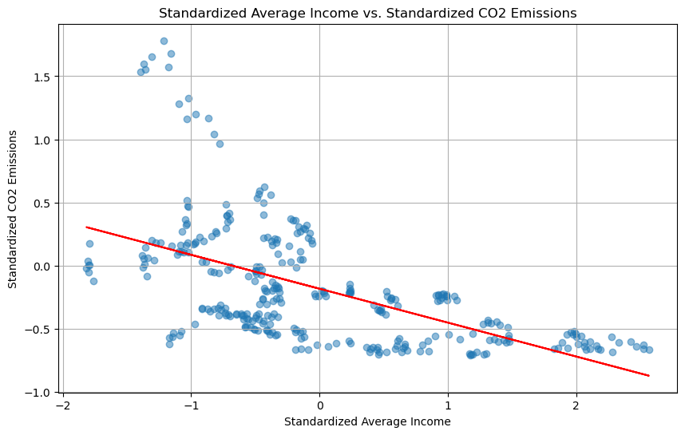

```python
# filter outliers
filtered_df = merged_df[merged_df['Standardized CO2 Emissions'] <= 3]
# create a scatter plot
plt.figure(figsize=(10, 6))
plt.scatter(filtered_df['Standardized Average Income'], filtered_df['Standardized CO2 Emissions'], alpha=0.5)
plt.title('Standardized Average Income vs. Standardized CO2 Emissions')
plt.xlabel('Standardized Average Income')
plt.ylabel('Standardized CO2 Emissions')
plt.grid(True)

x = filtered_df['Standardized Average Income']
y = filtered_df['Standardized CO2 Emissions']
coefficients = np.polyfit(x, y, 1) # linear regression line
regression_line = np.poly1d(coefficients)

# regression line
plt.plot(x, regression_line(x), color='red')

plt.show()
```

**We can see that the relationship may be not linear, so we try to use quadratic regression.**

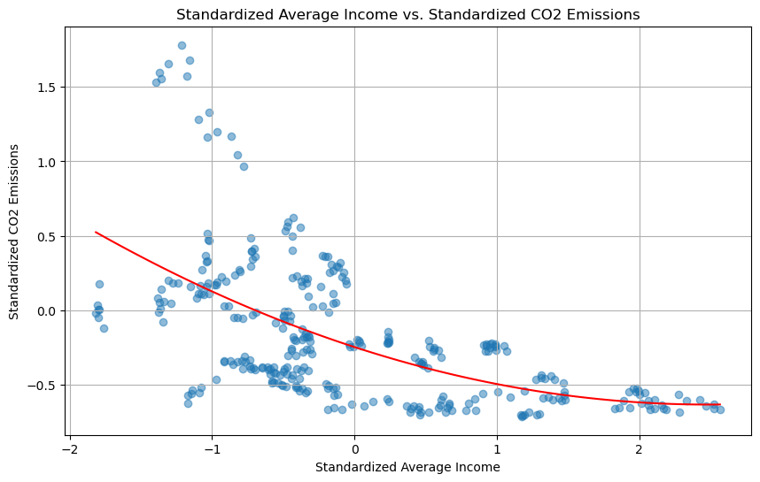

```python
plt.figure(figsize=(10, 6))
plt.scatter(filtered_df['Standardized Average Income'], filtered_df['Standardized CO2 Emissions'], alpha=0.5)
plt.title('Standardized Average Income vs. Standardized CO2 Emissions')
plt.xlabel('Standardized Average Income')
plt.ylabel('Standardized CO2 Emissions')
plt.grid(True)

x = filtered_df['Standardized Average Income']
y = filtered_df['Standardized CO2 Emissions']

# polynomial curve instead of a linear regression line
coefficients = np.polyfit(x, y, 2)
regression_curve = np.poly1d(coefficients)

x_curve = np.linspace(x.min(), x.max(), 100)
y_curve = regression_curve(x_curve)

plt.plot(x_curve, y_curve, color='red')

plt.show()
```

**The model is still too loose, use Non-linear SVM and K-NN regression model, run cross validation, try to find the best fit model.**

### **Non-linear SVM:**

**First, we run a Grid Search over a possible set of values to get the best value of C and epsilon.**

```python
from sklearn.model_selection import GridSearchCV
from sklearn.svm import SVR
from sklearn.model_selection import train_test_split
from sklearn.metrics import mean_squared_error

# filter outliers
filtered_df = merged_df[merged_df['Standardized CO2 Emissions'] <= 3]

x = filtered_df['Standardized Average Income'].values.reshape(-1, 1)
y = filtered_df['Standardized CO2 Emissions'].values

# split the data into training and testing sets
x_train, x_test, y_train, y_test = train_test_split(x, y, test_size=0.2, random_state=42)

# grid
param_grid = {'C': np.arange(0.1, 10, 0.1), 'epsilon': np.arange(0.1, 1, 0.1)}
svm_regressor = SVR(kernel='rbf')

grid_search = GridSearchCV(svm_regressor, param_grid, cv=5, scoring='neg_mean_squared_error')
grid_search.fit(x_train, y_train)

# best parameters
best_C = grid_search.best_params_['C']
best_epsilon = grid_search.best_params_['epsilon']
best_svm_regressor = SVR(kernel='rbf', C=best_C, epsilon=best_epsilon)
best_svm_regressor.fit(x_train, y_train)

y_pred = best_svm_regressor.predict(x_test)

mse = mean_squared_error(y_test, y_pred)
print(f"Best C: {best_C}")
print(f"Best epsilon: {best_epsilon}")
print(f"Mean Squared Error on Test Set: {mse}")
```

```
Best C: 9.6
Best epsilon: 0.2
Mean Squared Error on Test Set: 0.12808445234924687
```

**Use the best value of C and epsilon, do Non-linear SVM.**

```
R-squared: 0.3632914891641139
```

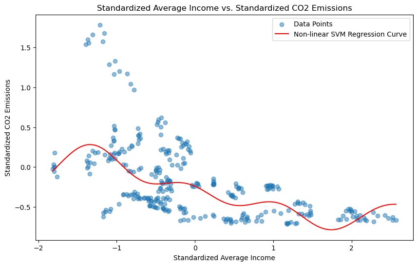

```
Correlation Coefficient: -0.5646390050839605
P-value: 1.6466689825984305e-28
R-squared: 0.3632914891641139
```

```python
from scipy.stats import pearsonr
from sklearn.metrics import r2_score

# filter outliers
filtered_df = merged_df[merged_df['Standardized CO2 Emissions'] <= 3]
x = filtered_df['Standardized Average Income'].values.reshape(-1, 1)
y = filtered_df['Standardized CO2 Emissions'].values

svm_regressor = SVR(kernel='rbf', C=9.6, epsilon=0.2)
model_svm = svm_regressor.fit(x, y)

x_curve = np.linspace(x.min(), x.max(), 100).reshape(-1, 1)
y_curve = svm_regressor.predict(x_curve)
y_pred = svm_regressor.predict(x)

# R-squared
r2 = r2_score(y, y_pred)

print(f'R-squared: {r2}')
plt.figure(figsize=(10, 6))
plt.scatter(x, y, label='Data Points', alpha=0.5)
plt.title('Standardized Average Income vs. Standardized CO2 Emissions')
plt.xlabel('Standardized Average Income')
plt.ylabel('Standardized CO2 Emissions')
plt.plot(x_curve, y_curve, color='red', label='Non-linear SVM Regression Curve')
plt.legend()
plt.show()
correlation_coefficient, p_value = pearsonr(x.flatten(), y)

print(f"Correlation Coefficient: {correlation_coefficient}")
print(f"P-value: {p_value}")
print(f'R-squared: {r2}')
```

## **K-NN regression:**

**First, we run a Grid Search over a possible set of values to get the best value of n_neighbors.**

```python
from sklearn.neighbors import KNeighborsRegressor

x = filtered_df['Standardized Average Income'].values.reshape(-1, 1)
y = filtered_df['Standardized CO2 Emissions'].values

# split the data into training and testing sets
x_train, x_test, y_train, y_test = train_test_split(x, y, test_size=0.2, random_state=42)

# grid
param_grid = {'n_neighbors': list(range(10, 50))}

knn_regressor = KNeighborsRegressor()
grid_search = GridSearchCV(knn_regressor, param_grid, cv=5, scoring='neg_mean_squared_error')
grid_search.fit(x_train, y_train)
best_n_neighbors = grid_search.best_params_['n_neighbors']

best_knn_regressor = KNeighborsRegressor(n_neighbors=best_n_neighbors)
best_knn_regressor.fit(x_train, y_train)

y_pred = best_knn_regressor.predict(x_test)

# evaluate the performance
mse = mean_squared_error(y_test, y_pred)
print(f"Best n_neighbors: {best_n_neighbors}")
print(f"Mean Squared Error on Test Set: {mse}")
```

```
Best n_neighbors: 31
Mean Squared Error on Test Set: 0.1253780336169973
```

**Use the best value of n_neighbors, do K-NN regression.**

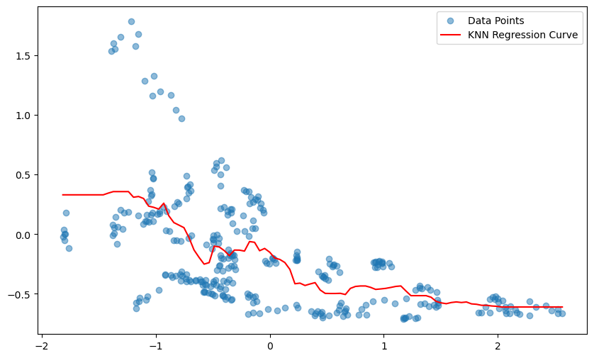

```python
x = filtered_df['Standardized Average Income'].values.reshape(-1, 1)
y = filtered_df['Standardized CO2 Emissions'].values

knn_regressor = KNeighborsRegressor(n_neighbors = 31)
model_knn = knn_regressor.fit(x, y)

x_curve = np.linspace(x.min(), x.max(), 100).reshape(-1, 1)
y_curve = knn_regressor.predict(x_curve)

plt.figure(figsize=(10, 6))
plt.scatter(x, y, label='Data Points', alpha=0.5)
plt.plot(x_curve, y_curve, color='red', label='KNN Regression Curve')
plt.legend()
plt.show()
```

## **Use 10-fold cross-validation**

Performance metric we used for regression model are Mean Squared Error (MSE) and Root Mean Squared Error (RMSE).

```python
from sklearn.model_selection import cross_val_score, KFold

x = filtered_df['Standardized Average Income'].values.reshape(-1, 1)
y = filtered_df['Standardized CO2 Emissions'].values

svm_regressor = SVR(kernel='rbf', C=9.6, epsilon=0.2)
knn_regressor = KNeighborsRegressor(n_neighbors=31)

kf = KFold(n_splits=10, shuffle=True, random_state=42)

svm_mse_scores = -cross_val_score(svm_regressor, x, y, cv=kf, scoring='neg_mean_squared_error')
svm_rmse_scores = np.sqrt(svm_mse_scores)
svm_mean_mse = np.mean(svm_mse_scores)
svm_mean_rmse = np.mean(svm_rmse_scores)

knn_mse_scores = -cross_val_score(knn_regressor, x, y, cv=kf, scoring='neg_mean_squared_error')
knn_rmse_scores = np.sqrt(knn_mse_scores)
knn_mean_mse = np.mean(knn_mse_scores)
knn_mean_rmse = np.mean(knn_rmse_scores)

print("Support Vector Machine (SVM) Cross-Validation Results:")
print(f"MSE Scores: {[round(score, 4) for score in svm_mse_scores]}")
print(f"RMSE Scores: {[round(score, 4) for score in svm_rmse_scores]}")
print(f"Mean MSE: {round(svm_mean_mse, 4)}")
print(f"Mean RMSE: {round(svm_mean_rmse, 4)}\n")

print("k-Nearest Neighbors (KNN) Cross-Validation Results:")
print(f"MSE Scores: {[round(score, 4) for score in knn_mse_scores]}")
print(f"RMSE Scores: {[round(score, 4) for score in knn_rmse_scores]}")
print(f"Mean MSE: {round(knn_mean_mse, 4)}")
print(f"Mean RMSE: {round(knn_mean_rmse, 4)}")
```

```
Support Vector Machine (SVM) Cross-Validation Results:
MSE Scores: [0.1608, 0.0965, 0.1726, 0.2885, 0.1057, 0.1651, 0.1803, 0.1196, 0.0879, 0.1209]
RMSE Scores: [0.4009, 0.3106, 0.4155, 0.5372, 0.3251, 0.4063, 0.4247, 0.3459, 0.2965, 0.3478]
Mean MSE: 0.1498
Mean RMSE: 0.381

k-Nearest Neighbors (KNN) Cross-Validation Results:
MSE Scores: [0.1602, 0.0906, 0.1675, 0.2595, 0.1371, 0.1577, 0.175, 0.1229, 0.109, 0.1136]
RMSE Scores: [0.4003, 0.301, 0.4093, 0.5094, 0.3702, 0.3971, 0.4184, 0.3506, 0.3301, 0.3371]
Mean MSE: 0.1493
Mean RMSE: 0.3823
```

### **Run a statistical test (paired t-test)**

```python
from scipy.stats import ttest_rel

mse_t_stat, mse_p_value = ttest_rel(svm_mse_scores, knn_mse_scores)

rmse_t_stat, rmse_p_value = ttest_rel(svm_rmse_scores, knn_rmse_scores)

print("Paired t-test Results for MSE:")
print(f"T-statistic: {mse_t_stat}")
print(f"P-value: {mse_p_value}")

print("\nPaired t-test Results for RMSE:")
print(f"T-statistic: {rmse_t_stat}")
print(f"P-value: {rmse_p_value}")
```

```
Paired t-test Results for MSE:
T-statistic: 0.0935612196756004
P-value: 0.9275074604924808

Paired t-test Results for RMSE:
T-statistic: -0.18783436478310023
P-value: 0.8551731698028784
```

In both cases, the T-statistic are close to 0 and p-values are higher than 0.05, suggesting that there is not enough evidence to conclude that there is a significant difference in performance between SVM and KNN based on the chosen metrics (MSE and RMSE). So it support my performance comparison above that SVM and KNN have similar predictive performance on my dataset.

**Analysis of the models:**

Both models, SVM and KNN, have relatively similar mean MSE scores, indicating that they perform comparably on average across the 10 folds. The RMSE values, which provide a more interpretable measure of the average prediction error, are also quite close between the two models. These results suggest that, based on the mean MSE and RMSE, SVM and KNN have similar predictive performance on my dataset. So we can choose Non-linear SVM which is more interpretable.

**Results:**

Use the model we can use average income in a state to predict the annual CO2 emissions per capita. The model also shows the negative relationship between average income in a state and CO2 emissions per capita.

## **Proposed Model 2: Test if there is a correlation between average wage of car dealers and the workforce of car dealers in the state**

**I plan to test if there is a correlation between average wage of car dealers and the workforce of car dealers in the state.**

Independent Variable (X): Average Wage of Car Dealers in the State (USD)

Dependent Variable (Y): Workforce of Car Dealers in the State

Methodology: Linear Regression/Correlation Analysis

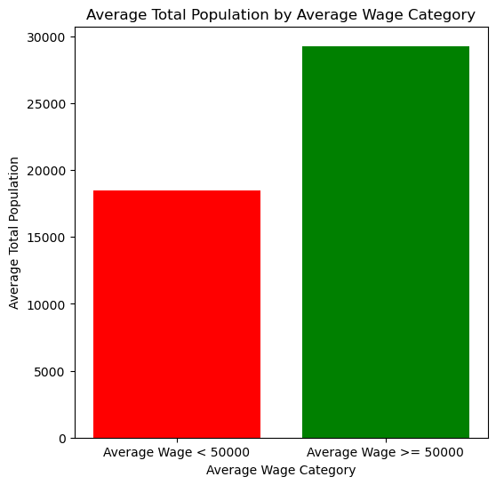

```python
avg_population_below_50000 = dealer[dealer['Average Wage(USD)'] < 50000]['Total Population'].mean()
avg_population_above_50000 = dealer[dealer['Average Wage(USD)'] >= 50000]['Total Population'].mean()

# bar plot
categories = ['Average Wage < 50000', 'Average Wage >= 50000']
average_population = [avg_population_below_50000, avg_population_above_50000]

plt.figure(figsize=(6, 6))
plt.bar(categories, average_population, color=['red', 'green'])
plt.title('Average Total Population by Average Wage Category')
plt.xlabel('Average Wage Category')
plt.ylabel('Average Total Population')
plt.show()
```

Draw a bar plot, we can find that when the average wage larger than 50000, the workforce is significantly larger.

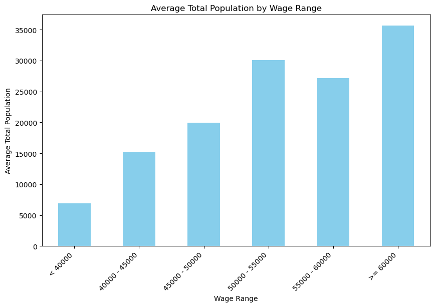

```python
bins = [float('-inf'), 40000, 45000, 50000, 55000, 60000, float('inf')]
labels = ['< 40000', '40000 - 45000', '45000 - 50000', '50000 - 55000', '55000 - 60000', '>= 60000']

dealer['Wage Range'] = pd.cut(dealer['Average Wage(USD)'], bins=bins, labels=labels, right=False)

average_population = dealer.groupby('Wage Range')['Total Population'].mean()

# bar plot
plt.figure(figsize=(10, 6))
average_population.plot(kind='bar', color='skyblue')
plt.title('Average Total Population by Wage Range')
plt.xlabel('Wage Range')
plt.ylabel('Average Total Population')
plt.xticks(rotation=45, ha='right')
plt.show()
```

Spilt more wage range to see the trend.

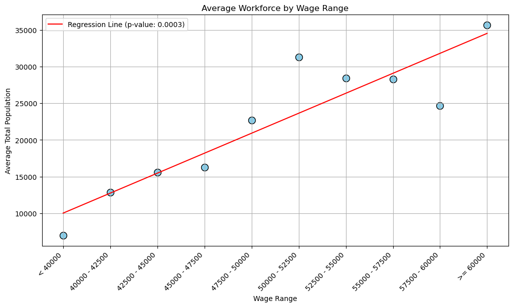

```python
bins = [float('-inf'), 40000, 42500, 45000, 47500, 50000, 52500, 55000, 57500, 60000, float('inf')]
labels = ['< 40000', '40000 - 42500', '42500 - 45000', '45000 - 47500','47500 - 50000', '50000 - 52500', '52500 - 55000', '55000 - 57500', '57500 - 60000', '>= 60000']

dealer['Wage Range'] = pd.cut(dealer['Average Wage(USD)'], bins=bins, labels=labels, right=False)
# average Total Population
average_population = dealer.groupby('Wage Range')['Total Population'].mean()

# scatter plot
plt.figure(figsize=(12, 6))
plt.scatter(average_population.index, average_population, color='skyblue', s=100, edgecolor='black')

# linear regression
x_values = np.arange(len(average_population))
slope, intercept, r_value, p_value, _ = linregress(x_values, average_population)
regression_line = slope * x_values + intercept
plt.plot(x_values, regression_line, color='red', label=f'Regression Line (p-value: {p_value:.4f})')

plt.title('Average Workforce by Wage Range')
plt.xlabel('Wage Range')
plt.ylabel('Average Total Population')
plt.xticks(x_values, average_population.index, rotation=45, ha='right')
plt.legend()
plt.grid(True)
plt.show()
```

```python
correlation_coefficient, p_value_correlation = pearsonr(dealer['Average Wage(USD)'], dealer['Total Population'])

print(f'Correlation Coefficient: {correlation_coefficient:.4f}')
print(f'P-value: {p_value_correlation:.4f}')
```

```
Correlation Coefficient: 0.1937
P-value: 0.0003
```

**Result: As we can see, there is a positive correlation between average wage of car dealers and the workforce of car dealers in the state.**

## **Proposed Model 3: Test if there is a correlation between mutiple factors (average temperature/workforce/income) of car dealer and CO2 emission in the state**

Independent Variable (X): Average Temperature/Workforce of car dealer in the State

Dependent Variable (Y): Annual CO2 Emissions per Capita (Metric Tons)

Methodology: Linear Regression

**Linear model between Average Temperature and CO2 Emissions per Capita**

```python
average_emission_by_year = merged_df.groupby('Year')['Annual CO2 Emissions per Capita (Metric Tons)'].transform('mean')
std_dev_emission_by_year = merged_df.groupby('Year')['Annual CO2 Emissions per Capita (Metric Tons)'].transform('std')

merged_df['Standardized CO2 Emissions'] = (merged_df['Annual CO2 Emissions per Capita (Metric Tons)'] - average_emission_by_year) / std_dev_emission_by_year

average_tem_by_year = merged_df.groupby('Year')['Temperature'].transform('mean')
std_dev_tem_by_year = merged_df.groupby('Year')['Temperature'].transform('std')

merged_df['Standardized Temperature'] = (merged_df['Temperature'] - average_tem_by_year) / std_dev_tem_by_year
```

```
R-squared: 0.036601653630455644
Correlation Coefficient: 0.191315586480704
P-value: 0.00055723066768474
```

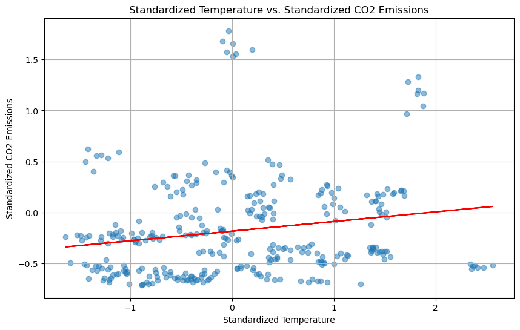

```python
# filter outliers
from sklearn.metrics import r2_score
from scipy.stats import pearsonr

filtered_df1 = merged_df[merged_df['Standardized CO2 Emissions'] <= 3]
# create a scatter plot
plt.figure(figsize=(10, 6))
plt.scatter(filtered_df1['Standardized Temperature'], filtered_df1['Standardized CO2 Emissions'], alpha=0.5)
plt.title('Standardized Temperature vs. Standardized CO2 Emissions')
plt.xlabel('Standardized Temperature')
plt.ylabel('Standardized CO2 Emissions')
plt.grid(True)

x = filtered_df1['Standardized Temperature']
y = filtered_df1['Standardized CO2 Emissions']
coefficients = np.polyfit(x, y, 1) # linear regression line
regression_line = np.poly1d(coefficients)

# regression line
plt.plot(x, regression_line(x), color='red')
# Calculate R-squared
r_squared = r2_score(y, regression_line(x))
print(f"R-squared: {r_squared}")

# correlation coefficient and p-value
correlation_coefficient, p_value = pearsonr(x, y)

print(f"Correlation Coefficient: {correlation_coefficient}")
print(f"P-value: {p_value}")
plt.show()
```

The low R-squared implies that the model may not be a good fit for the data, and the predicted values do not closely match the observed values.

**Linear model between Workforce and CO2 Emissions per Capita**

```python
average_emission_by_year = merged_df.groupby('Year')['Annual CO2 Emissions per Capita (Metric Tons)'].transform('mean')
std_dev_emission_by_year = merged_df.groupby('Year')['Annual CO2 Emissions per Capita (Metric Tons)'].transform('std')

merged_df['Standardized CO2 Emissions'] = (merged_df['Annual CO2 Emissions per Capita (Metric Tons)'] - average_emission_by_year) / std_dev_emission_by_year

average_force_by_year = merged_df.groupby('Year')['Total Population'].transform('mean')
std_dev_force_by_year = merged_df.groupby('Year')['Total Population'].transform('std')

merged_df['Standardized workforce'] = (merged_df['Total Population'] - average_force_by_year) / std_dev_force_by_year
```

```
R-squared: 0.03601665841824753
Correlation Coefficient: -0.18978055331947835
P-value: 0.0006184077372541325
```

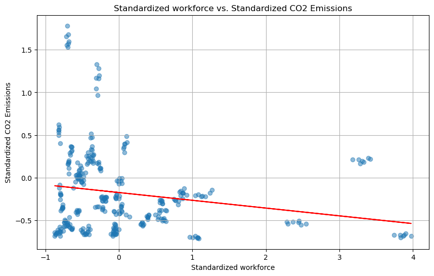

```python
# filter outliers
from sklearn.metrics import r2_score
from scipy.stats import pearsonr

filtered_df2 = merged_df[merged_df['Standardized CO2 Emissions'] <= 3]
# create a scatter plot
plt.figure(figsize=(10, 6))
plt.scatter(filtered_df2['Standardized workforce'], filtered_df2['Standardized CO2 Emissions'], alpha=0.5)
plt.title('Standardized workforce vs. Standardized CO2 Emissions')
plt.xlabel('Standardized workforce')
plt.ylabel('Standardized CO2 Emissions')
plt.grid(True)

x = filtered_df2['Standardized workforce']
y = filtered_df2['Standardized CO2 Emissions']
coefficients = np.polyfit(x, y, 1) # linear regression line
regression_line = np.poly1d(coefficients)

# regression line
plt.plot(x, regression_line(x), color='red')
# Calculate R-squared
r_squared = r2_score(y, regression_line(x))
print(f"R-squared: {r_squared}")

# correlation coefficient and p-value
correlation_coefficient, p_value = pearsonr(x, y)

print(f"Correlation Coefficient: {correlation_coefficient}")
print(f"P-value: {p_value}")
plt.show()
```

The low R-squared implies that the model may not be a good fit for the data, and the predicted values do not closely match the observed values.

### **Try to build a model with mutiple independent variables.**

```python
import statsmodels.api as sm
merged_df.dropna(subset=['Standardized CO2 Emissions', 'Standardized Average Income', 'Standardized Temperature'], inplace=True)

X = merged_df[['Standardized Average Income', 'Standardized Temperature','Standardized workforce']]
y = merged_df['Annual CO2 Emissions per Capita (Metric Tons)']

# add constant term to the predictors
X = sm.add_constant(X)

model = sm.OLS(y, X).fit()

print(model.summary())
```

```
                                          OLS Regression Results
=========================================================================================================
Dep. Variable:     Annual CO2 Emissions per Capita (Metric Tons)   R-squared:                       0.114
Model:                                                       OLS   Adj. R-squared:                  0.106
Method:                                            Least Squares   F-statistic:                     14.30
Date:                                           Thu, 14 Dec 2023   Prob (F-statistic):           8.72e-09
Time:                                                   00:01:21   Log-Likelihood:                -1412.8
No. Observations:                                            336   AIC:                             2834.
Df Residuals:                                                332   BIC:                             2849.
Df Model:                                                      3
Covariance Type:                                       nonrobust
===============================================================================================
                                  coef    std err          t      P>|t|      [0.025      0.975]
-----------------------------------------------------------------------------------------------
const                          20.7085      0.890     23.272      0.000      18.958      22.459
Standardized Average Income    -4.4859      1.028     -4.364      0.000      -6.508      -2.464
Standardized Temperature       -3.6601      1.129     -3.242      0.001      -5.881      -1.439
Standardized workforce         -2.1909      1.049     -2.088      0.038      -4.255      -0.126
==============================================================================
Omnibus:                      255.278   Durbin-Watson:                   2.096
Prob(Omnibus):                  0.000   Jarque-Bera (JB):             2735.342
Skew:                           3.238   Prob(JB):                         0.00
Kurtosis:                      15.388   Cond. No.                         2.02
==============================================================================

Notes:
[1] Standard Errors assume that the covariance matrix of the errors is correctly specified.
```

R-squared become higher but still quite low, imply:

①Some factors influencing emissions may not be captured by the current set of variables.

②Linear model not fit for the data.

**Add interaction term:**

```python
merged_df['Income_Temperature_Interact'] = merged_df['Standardized Average Income'] * merged_df['Standardized Temperature']
merged_df['Income_Workforce_Interact'] = merged_df['Standardized workforce'] * merged_df['Standardized Average Income']
merged_df['Temperature_Workforce_Interact'] = merged_df['Standardized workforce'] * merged_df['Standardized Temperature']
# Define predictors and response variable
X = merged_df[['Standardized Average Income', 'Standardized Temperature', 'Standardized workforce', 'Income_Temperature_Interact','Income_Workforce_Interact','Temperature_Workforce_Interact']]
y = merged_df['Annual CO2 Emissions per Capita (Metric Tons)']

# Add a constant term to the predictors
X = sm.add_constant(X)

# Fit the OLS regression model
model = sm.OLS(y, X).fit()

# Print the model summary
print(model.summary())
```

```
                                          OLS Regression Results
=========================================================================================================
Dep. Variable:     Annual CO2 Emissions per Capita (Metric Tons)   R-squared:                       0.197
Model:                                                       OLS   Adj. R-squared:                  0.182
Method:                                            Least Squares   F-statistic:                     13.42
Date:                                           Thu, 14 Dec 2023   Prob (F-statistic):           1.28e-13
Time:                                                   00:01:22   Log-Likelihood:                -1396.5
No. Observations:                                            336   AIC:                             2807.
Df Residuals:                                                329   BIC:                             2834.
Df Model:                                                      6
Covariance Type:                                       nonrobust
==================================================================================================
                                     coef    std err          t      P>|t|      [0.025      0.975]
--------------------------------------------------------------------------------------------------
const                             16.9346      1.154     14.676      0.000      14.665      19.205
Standardized Average Income       -4.0863      1.059     -3.859      0.000      -6.169      -2.003
Standardized Temperature          -4.6188      1.198     -3.855      0.000      -6.976      -2.262
Standardized workforce            -5.6411      1.404     -4.018      0.000      -8.403      -2.879
Income_Temperature_Interact       -4.3306      1.314     -3.297      0.001      -6.915      -1.747
Income_Workforce_Interact          1.7948      1.681      1.068      0.286      -1.512       5.102
Temperature_Workforce_Interact     4.7223      0.988      4.780      0.000       2.779       6.666
==============================================================================
Omnibus:                      209.045   Durbin-Watson:                   2.087
Prob(Omnibus):                  0.000   Jarque-Bera (JB):             1676.237
Skew:                           2.565   Prob(JB):                         0.00
Kurtosis:                      12.665   Cond. No.                         4.08
==============================================================================

Notes:
[1] Standard Errors assume that the covariance matrix of the errors is correctly specified.
```

**We can find that use interaction term can further improve the model. But still, it can not explain much of the variation in CO2 Emissions per Capita, suggests that some factors influencing emissions may not be captured by the current set of variables.**

# **Part 5: Conclusion, Recommendation and Further Study**

### **Colclusion:**

**The analysis of the relationship between average income and CO2 emissions reveals a discernible trend, indicating that as states experience economic development, there is a corresponding reduction in their carbon footprint. This correlation suggests a multifaceted association between economic prosperity and environmental consciousness. Several key factors contribute to this observed relationship.**

1. **Economic Development as a Catalyst for Environmental Stewardship:** The correlation underscores the idea that economic development acts as a catalyst for heightened environmental stewardship. States with higher incomes are likely to prioritize sustainable practices and invest in strategies to mitigate their impact on the environment.
2. **Adoption of Cleaner Technologies:** The positive correlation between higher income levels and lower CO2 emissions implies a greater propensity for the adoption of cleaner and more energy-efficient technologies. Wealthier states are better positioned to invest in and embrace innovations that contribute to a more sustainable and eco-friendly future.
3. **Policy and Regulatory Frameworks:** State-level policies and regulatory frameworks play a pivotal role in shaping environmental outcomes. Wealthier states, with greater resources at their disposal, are more adept at implementing and enforcing stringent policies that mandate environmentally sustainable practices across industries and sectors.

### **Recommendations:**

1. **Promote Sustainable Practices in Lower-Income States:** Initiate targeted programs and educational campaigns to promote sustainable practices in lower-income states. Provide resources and guidance to facilitate the adoption of eco-friendly technologies and practices.
2. **Advocate for Investments in Affordable Green Technologies:** Advocate for increased investments in cost-effective green technologies and infrastructure. Focus on making these technologies financially accessible to states with lower average incomes, fostering a transition to cleaner energy sources.
3. **Implement Financial Incentives:** Consider implementing financial incentives, such as tax credits or subsidies, to businesses and individuals in states with lower average incomes. These incentives can serve as catalysts for the adoption of sustainable technologies and practices, aligning economic development with environmental responsibility.

The comprehensive analysis undertaken in this project has revealed that while a discernible trend exists between average income and CO2 emissions, establishing an accurate predictive model for emissions based on multiple variables poses challenges. The intricacies of CO2 emissions are governed by a multitude of factors, and the current set of variables may not comprehensively capture all influencing elements.

Within the confines of this project's scope, limitations were encountered in expanding the model's variables to comprehensively illustrate the causes of CO2 emissions. However, the notebook aims to establish a foundational reference, offering initial insights into the factors influencing CO2 emissions and their interrelationships for future study.